# Clustering Lab

Briana Barajas

2024-02-29

## Demo

We’ll start off with some simulated data that has a structure that is amenable to clustering analysis.

```r
#Set the parameters of our simulated data
set.seed(101)

# simulating data that has clear clusters
cents <- tibble(
  cluster = factor(1:3), # set to have 3 clusters

  num_points = c(100, 150, 50), # define size of clusters

  x1 = c(5, 0, -3), # coordinates for center of cluster
  x2 = c(-1, 1, -2)

)
```

So in this simulated data, the first cluster will be 100 points and the center will be at (5,-1).

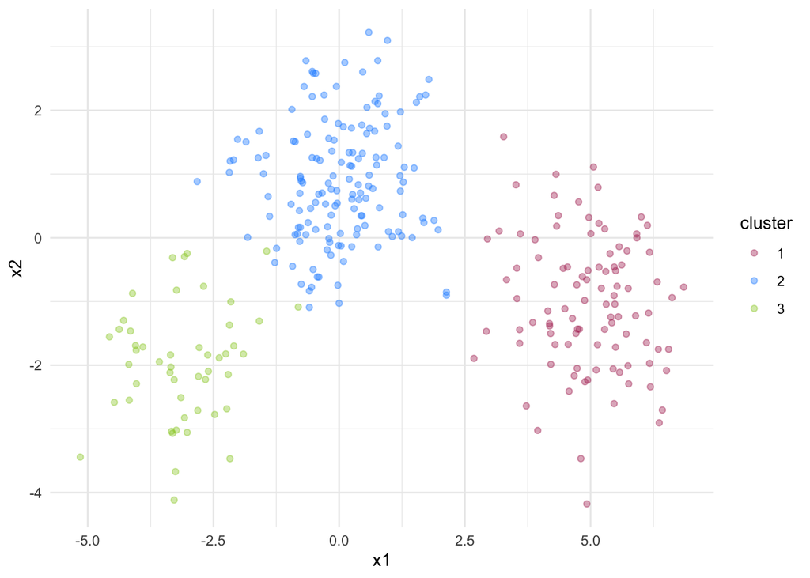

```r
#Simulate the data by passing n and mean to rnorm using map2()
labelled_pts <- cents %>%

  mutate(
    # create a series of coordinates that correspond to all 100 points in cluster1
    x1 = map2(num_points, x1, rnorm),
    x2 = map2(num_points, x2, rnorm)) %>%

  select(-num_points) %>%
  unnest(cols=c(x1, x2))

# plot points
ggplot(labelled_pts, aes(x1, x2, col = cluster)) +
  geom_point(alpha = 0.4) +
  scale_color_manual(values = c("maroon", "dodgerblue", "yellowgreen")) +
  theme_minimal()
```

**NOTE:** `map()` applies a function to a list, `map2()` is applying two functions to a list. In this case, we are applying the `rnorm` function.

```r
# remove cluster column so model only knows coordinates, not groups
points <- labelled_pts %>%
  select(-cluster)

# input data, and parameter k (k = number of cluster centers)
# we're using 3 because we know that's the true value, but this isn't always the case
kclust <- kmeans(points, centers = 3, n = 25)
kclust
```

```
## K-means clustering with 3 clusters of sizes 48, 100, 152
##
## Cluster means:
##             x1         x2
## 1 -3.194015379 -2.0272690
## 2  4.962808900 -1.0254665
## 3 -0.004476705  0.8627456
##
## Clustering vector:
##   [1] 2 2 2 2 2 2 2 2 2 2 2 2 2 2 2 2 2 2 2 2 2 2 2 2 2 2 2 2 2 2 2 2 2 2 2 2 2
##  [38] 2 2 2 2 2 2 2 2 2 2 2 2 2 2 2 2 2 2 2 2 2 2 2 2 2 2 2 2 2 2 2 2 2 2 2 2 2
##  [75] 2 2 2 2 2 2 2 2 2 2 2 2 2 2 2 2 2 2 2 2 2 2 2 2 2 2 3 3 3 3 3 3 3 3 3 3 3
## [112] 3 3 3 3 3 3 3 3 3 3 3 3 3 3 3 3 3 3 3 3 3 3 3 3 3 3 3 3 3 3 3 3 3 3 3 3 3
## [149] 3 3 3 3 3 3 3 3 3 3 3 3 3 3 3 3 3 3 3 3 3 3 3 3 3 3 3 3 3 3 3 3 3 3 3 3 3
## [186] 3 3 3 3 3 3 3 3 3 3 3 3 3 3 3 3 3 3 3 3 3 3 3 3 3 3 3 3 3 3 3 3 3 3 3 3 3
## [223] 3 3 3 3 3 3 3 3 3 3 3 3 3 3 3 3 3 3 3 3 3 3 3 3 3 3 3 3 1 1 1 1 1 1 1 1 1
## [260] 1 1 1 3 1 3 1 1 1 1 1 1 1 1 1 1 1 1 1 1 1 1 1 1 1 1 1 1 1 1 1 1 1 1 1 1 1
## [297] 1 1 1 1
##
## Within cluster sum of squares by cluster:
## [1]  66.89755 195.90406 277.61532
##  (between_SS / total_SS =  84.6 %)
##
## Available components:
##
## [1] "cluster"      "centers"      "totss"        "withinss"     "tot.withinss"
## [6] "betweenss"    "size"         "iter"         "ifault"
```

```r
#now let's try a systematic method for setting k
kclusts <- tibble(k = 1:9) %>% # trying values of k from 1-9

  mutate(
    #running kmeans function were points is the data, and we're returning a single list of k-values. Using map() since returning one list
    kclust = map(k, ~kmeans(points, .x)),
    augmented = map(kclust, augment, points)
  )
```

```r
#append cluster assignment to tibble
# assignments is which cluster each point is associated with
assignments <- kclusts %>% unnest(cols = c(augmented))
head(assignments, 2)
```

```
## # A tibble: 2 × 5
##       k kclust      x1    x2 .cluster
##   <int> <list>   <dbl> <dbl> <fct>
## 1     1 <kmeans>  4.67 -2.17 1
## 2     1 <kmeans>  5.55 -1.24 1
```

**NOTE:** Unnesting allows you to view each model run, where each model differs by the number of centers.

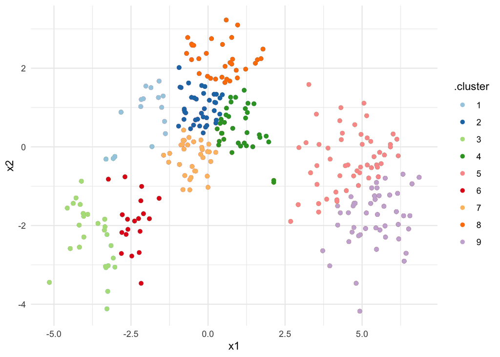

```r
#Plot each model to view clusters created by the model
p1 <- ggplot(assignments, aes(x1, x2, col = .cluster), alpha = 0.8) +
  geom_point() +
  scale_color_brewer(palette = "Paired") + theme_minimal()

p1
```

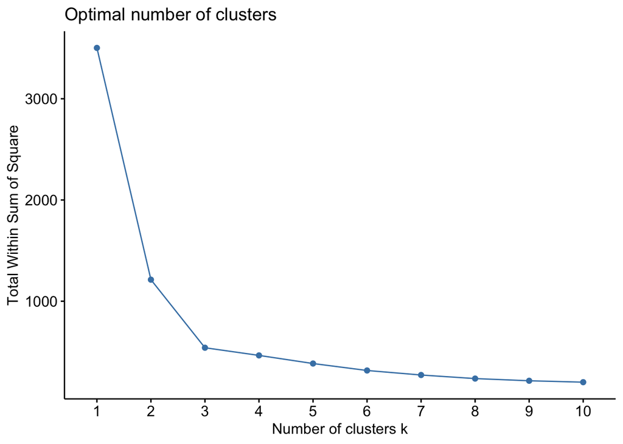

```r
#Use a clustering function from {factoextra} to plot  total WSSs
fviz_nbclust(points, kmeans, "wss")
```

**NOTE:** Created a plot using `fviz_nbclust` to find the elbow. Based on the plot, it seems like the best value of k is around 3. After 3, there are not large improvements in WSS.

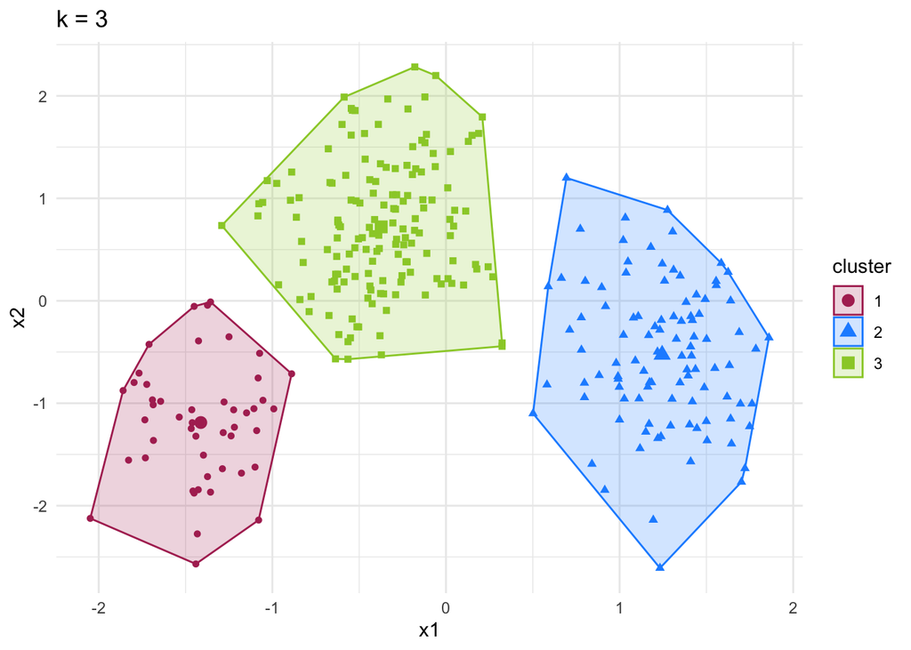

```r
#Another plotting method
k3 <- kmeans(points, centers = 3, nstart = 25)

p3 <- fviz_cluster(k3, geom = "point", data = points) +
  ggtitle("k = 3") +
  theme_minimal() +
  scale_color_manual(values = c("maroon", "dodgerblue", "yellowgreen")) +
  scale_fill_manual(values = c("maroon", "dodgerblue", "yellowgreen"))

p3
```

## In-class assignment!

Now it’s your turn to partition a dataset. For this round we’ll use data from Roberts et al. 2008 on bio-contaminants in Sydney Australia’s Port Jackson Bay. The data are measurements of metal content in two types of co-occurring algae at 10 sample sites around the bay.

```r
#Read in data
metals_dat <- readr::read_csv(here::here("demo", "data", "w8-harbour_metals.csv"))

# Inspect the data
head(metals_dat, 4) %>% gt::gt()
```

| Location | Species | Rep | Cd | Cr | Cu | Mn | Ni | Pb | Zn |
| --- | --- | --- | --- | --- | --- | --- | --- | --- | --- |
| Balls Head | Padina | P.13 | 0.67 | 3.82 | 68.92 | 106.94 | 1.52 | 32.62 | 96.52 |
| Balls Head | Padina | P.14 | 0.50 | 5.84 | 93.50 | 81.98 | 2.74 | 28.77 | 134.64 |
| Balls Head | Padina | P.15 | 0.66 | 9.04 | 116.02 | 124.26 | 3.17 | 62.13 | 150.57 |
| Balls Head | Padina | P.16 | 0.89 | 4.93 | 110.55 | 155.92 | 2.43 | 52.46 | 113.51 |

```r
metals_dat %>%
  summarise(Cd_mean = mean(Cd),
            Cr_mean = mean(Cr),
            Cu_mean = mean(Cu),
            Mn_mean = mean(Mn),
            Ni_mean = mean(Ni),
            Pb_mean = mean(Pb),
            Zn_mean = mean(Zn)) %>% gt::gt()
```

| Cd_mean | Cr_mean | Cu_mean | Mn_mean | Ni_mean | Pb_mean | Zn_mean |
| --- | --- | --- | --- | --- | --- | --- |
| 1.271 | 4.9705 | 57.4055 | 54.33767 | 2.131167 | 75.43667 | 110.525 |

```r
#Grab pollutant variables
metals_dat2 <- metals_dat[, 4:8]
```

1. Start with k-means clustering - `kmeans()`. You can start with `fviz_nbclust()` to identify the best value of k. Then plot the model you obtain with the optimal value of k.

Do you notice anything different about the spacing between clusters? Why might this be?

Run `summary()` on your model object. Does anything stand out?

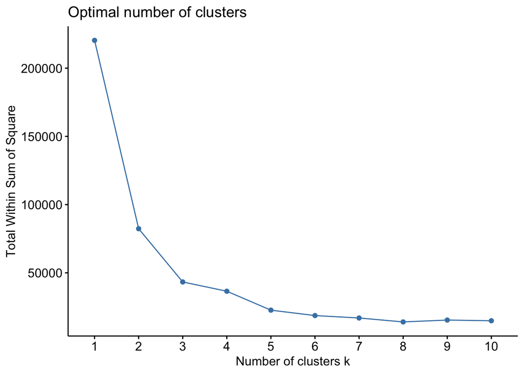

```r
# determine the best value of k, in this case we'll use 3
fviz_nbclust(metals_dat2, kmeans, "wss")
```

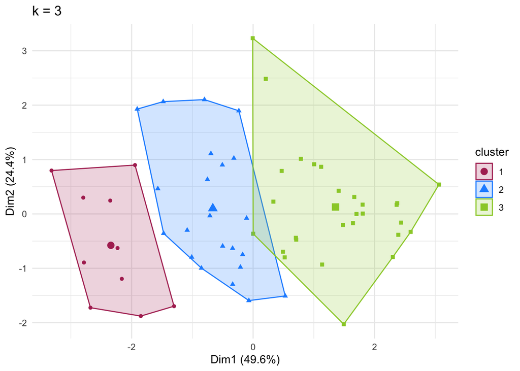

```r
# calculate kmeans using k=3
k3 <- kmeans(metals_dat2, centers = 3, n = 25)

# visualize the model
fviz_cluster(k3, geom = "point", data = metals_dat2) +
  ggtitle("k = 3") +
  theme_minimal() +
  scale_color_manual(values = c("maroon", "dodgerblue", "yellowgreen")) +
  scale_fill_manual(values = c("maroon", "dodgerblue", "yellowgreen"))
```

```r
# view summary
k3
```

```
## K-means clustering with 3 clusters of sizes 10, 22, 28
##
## Cluster means:
##         Cd       Cr        Cu        Mn    Ni
## 1 0.796000 6.530000 127.09000 126.28200 2.304
## 2 1.076818 6.180455  70.28455  66.79864 2.385
## 3 1.593214 3.462857  22.39893  18.85250 1.870
##
## Clustering vector:
##  [1] 2 2 1 1 1 1 3 2 2 2 2 2 2 2 1 2 2 1 3 3 3 3 3 3 3 3 2 2 2 2 3 3 3 3 3 3 1 3
## [39] 2 3 2 2 3 3 3 3 3 3 2 1 1 2 1 2 2 3 3 3 3 3
##
## Within cluster sum of squares by cluster:
## [1] 13159.695 22633.706  7511.094
##  (between_SS / total_SS =  80.4 %)
##
## Available components:
##
## [1] "cluster"      "centers"      "totss"        "withinss"     "tot.withinss"
## [6] "betweenss"    "size"         "iter"         "ifault"
```

2. Good, now let’s move to hierarchical clustering that we saw in lecture. The first step for that is to calculate a distance matrix on the data (using `dist()`). Euclidean is a good choice for the distance method.

```r
# calculate the distance matrix
distance <- dist(metals_dat2, method = "euclidean")
```

2. Use `tidy()` on the distance matrix so you can see what is going on. What does each row in the resulting table represent?

```r
distance_tidy <- broom::tidy(distance)
head(distance_tidy, 5) %>% gt::gt()
```

| item1 | item2 | distance |
| --- | --- | --- |
| 1 | 2 | 35.11091 |
| 1 | 3 | 50.48132 |
| 1 | 4 | 64.29779 |
| 1 | 5 | 72.51512 |
| 1 | 6 | 72.61565 |

**ANS:** The `item1` and `item2` columns represent a pairing of two data points, and the `distance` column is the calculated Euclidean distance between those two points.

3. Then apply hierarchical clustering with hclust().

```r
# apply hierarchical clustering
metals_clust <- hclust(distance)
```

4. Now plot the clustering object. You can use something of the form plot(as.dendrogram()). Or you can check out the cool visual options here: https://rpubs.com/gaston/dendrograms

How does the plot look? Do you see any outliers? How can you tell?

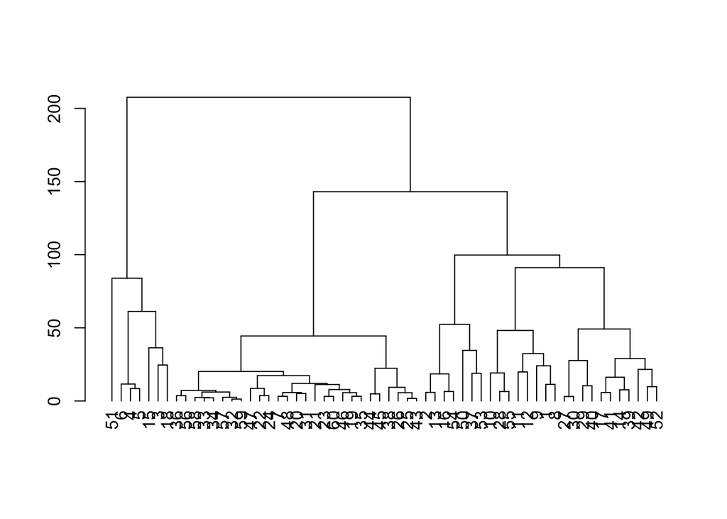

```r
plot(as.dendrogram(metals_clust))
```

**ANS:** Point 51 appears to be an outlier. The height of the dendrogram represents the distance, and there is a very large distance between this point and the other points it is clustered with.